# Basics of Text Classification

*By Charlotte Gils*

The goal of this tutorial is to introduce the basic concepts of building a text classification model.

We consider a data set of Medium articles, which can be found at www.kaggle.com.

**The goal of the model is to assign a topic tag to an article, based on the article's title, subtitle, author, and publication.**

For educational purposes, the original data set has been reduced, and the problem has been simplified:

- We consider only articles that have a single tag (we will not consider a multilabel classification problem here)
- Only articles with both a title and a subtitle are considered (note that this impacts the applicability of the model)
- To further simplify the problem for educational purposes, we retain only the top 4 categories. Note that - as a result - our model is applicable only to articles that are in one of these 4 categories.

## I Data Exploration and Preparation

Typically, we'd want to explore our data set in detail before starting to model.

In particular, we'd want to understand the quality of the labels in the training data, and the specifics of the input text considered.

Here, we will it short due to time constraints.

```python
import pandas as pd
import numpy as np
df = pd.read_csv("Medium_SingleLabel.csv")
print ("Number of articles: {}".format(len(df)))
```

```
Number of articles: 76744
```

```python
df_all.head(2)
```

|  | Unnamed: 0 | Title | Subtitle | Image | Author | Publication | Year | Month | Day | Reading_Time | ... | Tag_travel | Tag_trump | Tag_ux | Tag_venture-capital | Tag_web-design | Tag_web-development | Tag_women | Tag_wordpress | Tag_work | Tag_writing |
| --- | --- | --- | --- | --- | --- | --- | --- | --- | --- | --- | --- | --- | --- | --- | --- | --- | --- | --- | --- | --- | --- |
| 0 | 2 | Online Animation: Mixamo vs Norah AI | Online animations tools provide game designers... | 1 | Emma Laurent | NaN | 2017 | 8 | 1 | 5 | ... | 0 | 0 | 0 | 0 | 0 | 0 | 0 | 0 | 0 | 0 |
| 1 | 5 | A.I. ? | NaN | 0 | Sanparith Marukatat | NaN | 2017 | 8 | 1 | 2 | ... | 0 | 0 | 0 | 0 | 0 | 0 | 0 | 0 | 0 | 0 |

2 rows × 108 columns

The included texts are quite short:

```python
print ("Maximum # characters among all subtitles: {}".format(df["Subtitle"].astype(str).apply(lambda x: len(x) if x is not None else 0).max()))
```

```
Maximum # characters among all subtitles: 369
```

The distribution of classes is quite balanced:

```python
df["label"].value_counts()/len(df)
```

```
Tag_travel    0.278276
Tag_music     0.259095
Tag_health    0.233608
Tag_food      0.229021
Name: label, dtype: float64
```

```python
print ("Number of distinct authors: {}".format(len(df["Author"].value_counts())))
print ("Proportion of authors that appear only once: {}".format(
            np.sum([c for c in df["Author"].value_counts() if c ==1])/len(df)))
print ("Top authors: \n{}".format(df["Author"].value_counts()[:5]))
```

```
Number of distinct authors: 38972
Proportion of authors that appear only once: 0.36018450953820497
Top authors:
Samantha Bambino        452
                        238
Pushpitha Wijesinghe    198
Gareth Johnson          194
Donna-Claire Chesman    172
Name: Author, dtype: int64
```

```python
print ("Number of distinct publications: {}".format(len(df["Publication"].value_counts())))
print ("Proportion of publications that appear only once: {}".format(
            np.sum([c for c in df["Publication"].value_counts() if c ==1])/len(df)))
print ("Top authors: \n{}".format(df["Publication"].value_counts()[:5]))
```

```
Number of distinct publications: 4423
Proportion of publications that appear only once: 0.033240383613051185
Top authors:
MEL Magazine                         299
The Audiomack Blog                   174
Northeast Times                      155
Thrive Global                        152
Japan Travel GuideJW Web Magazine    118
Name: Publication, dtype: int64
```

Combine all four text fields:

```python
for col in ["Title", "Subtitle", "Author", "Publication"]:
    df[col] = df[col].fillna("")
    df["all_text"] += " "  + df[col]
```

Create Test/Holdout Set not Used in Model Training:

```python
from sklearn import model_selection
df_train, df_test, y_train, y_test = model_selection.train_test_split(\
        df, df["label"], stratify = df["label"] ,random_state= 11, test_size = 0.3)
print (len(df_train), len(df_test))
```

```
53720 23024
```

## II Feature Engineering

### A) Tokenize

Split the text into its constituent words.

Note that there is no one tokenizer that works for all types of texts; **tuning the tokenizer is part of feature engineering**.

```python
print ("This won't (really) cut it!".split())
print (nltk.regexp_tokenize("This won't cut (it) either!", "\w+"))
```

```
['This', "won't", '(really)', 'cut', 'it!']
['This', 'won', 't', 'cut', 'it', 'either']
```

```python
text = """
        This is (much) BETTER. $1000 @hash4tag for great
        ideas on-the-go and conceptualization !!
        """
pattern =  "[\'A-z\-]+|[@\#]\w+"
print (nltk.regexp_tokenize(text, pattern))
```

```
['This', 'is', 'much', 'BETTER', '@hash4tag', 'for', 'great', 'ideas', 'on-the-go', 'and', 'conceptualization']
```

In addition, the following steps are typically taken:

- Convert all words to **lower case**, although we may want to retain all capitalized words
- **Remove stop words**
- **Stemming** (Optional: Sometimes this is useful but not always; there are multiple stemmers)
- Include higher-than 1 **ngrams**
- Remove words with less than 3 characters

```python
import nltk
from nltk.stem.snowball import SnowballStemmer
from nltk.corpus import stopwords
from nltk import ngrams
sw = set(stopwords.words('english'))
stemmer = SnowballStemmer("english")
pattern =  "[\'A-z\-]+|[@\#]\w+"

def tokenize(text, stem=False, n_grams=1 ):
    if text is None:
        return []
    tokens = [t.lower() for t in nltk.regexp_tokenize(text, pattern)]

    #remove stopwords and words with less than 3 charactesr
    tokens = [t for t in tokens if t not in sw and len(t) > 2]

    if stem == True:
        tokens = [stemmer.stem(t) for t in tokens]

    if n_grams > 1:
        copy_tokens = tokens.copy()
        for n in range(2, n_grams+1):
            tokens.extend(["_".join(list(g)) for g in ngrams(copy_tokens, n)])

    return tokens
```

```python
tokenize(text, stem=True, n_grams=2)
```

```
['much',
 'better',
 '@hash4tag',
 'great',
 'idea',
 'on-the-go',
 'conceptu',
 'much_better',
 'better_@hash4tag',
 '@hash4tag_great',
 'great_idea',
 'idea_on-the-go',
 'on-the-go_conceptu']
```

### B) Count Matrix (Bag-of-Words)

Each token corresponds to one variable, with value 0 (token not in document), or value ct (number of times the token appears in the document).

```python
args = { "stem": True, "n_grams":1}
countVect = feature_extraction.text.CountVectorizer(
                tokenizer=lambda text: tokenize(text, **args),
                lowercase=False,  min_df = 1)
X_train_c = countVect.fit_transform(df_train["all_text"])
```

```python
print ("# of features: {}".format(X_train_c.shape[1]))
inv_vocab = {v: k for k, v in countVect.vocabulary_.items()}
word_sums = X_train_c.toarray().sum(axis=0)
sorted_idx = np.argsort(word_sums)[::-1]
print ("Most common words:")
for i in sorted_idx[:10]:
    print (inv_vocab[i], X_train_c[:,i].sum())
```

```
# of features: 80751
Most common words:
music 11984
one 11564
food 11250
time 9606
travel 9336
best 9200
day 8392
new 7690
year 7308
get 7292
```

### C) Tfidf

Tfidf stands for **"term frequency-inverse document frequency"**:

- Term frequency (Tf): **Give more weight to words that appear more frequently within a document**
- Inverse document frequency (idf): **Reduce the weight of words that appear frequently across all documents**

Definitions:

- Tf(word): Number of times "word" appears in the document
- idf(word): Log( Number of documents / Number of documents where "word" appears))

```python
from sklearn import feature_extraction

def generate_features(args, df_train, df_test, min_word_ct = 1,):
    tfidfVect = feature_extraction.text.TfidfVectorizer(
                tokenizer=lambda text: tokenize(text, **args),
                lowercase=False,  min_df = min_word_ct)

    X_train =  tfidfVect.fit_transform(df_train["all_text"])
    X_test = tfidfVect.transform(df_test["all_text"])

    #scale to mean 0 and unit variance (allows to compare magnitudes of coefficients)
    scaler = preprocessing.StandardScaler(with_mean=False)
    X_train = sparse.csr_matrix(scaler.fit_transform(X_train.toarray()))
    X_test = sparse.csr_matrix(scaler.transform(X_test.toarray()))

    vocab = tfidfVect.vocabulary_

    return X_train, X_test, vocab
```

Note that we have combined all text fields into one field, but note that it might be advantageous to *retain the information on the field (title, subtitle, etc) where a token appeared* (we will not do that here).

## III Evaluation Metrics

Before we move to training a model, we need to decide how to evaluate the model!

In multi-class classification, one typically assesses performance using

**Precision(c)**: # samples correctly predicted to be in class c/ # samples predicted to be in class c

**Recall(c)**: # samples correctly predicted to be in class c / # samples actually in class c

The weighted **F1-score** is the sum of

2 *precision(c)* recall(c)/ (precision(c)+ recall(c)),

weighted by the sum of samples in class c

Note that business requirements typically dictate

- the appropriate evaluation metrics
- how high the evaluation must be

A model may be tuned to optimize the chosen metric (typically at the expense of other metrics; e.g., recall vs precision, class X vs class Y).

Below, we will tune our model based on weighted F1-score: I.e., we give equal weight to optimizing precision and recall, and give weight to classes based on their respective proportions in the data.

## IV Train Classification Model

```python
from sklearn import linear_model
from sklearn import metrics
from sklearn import preprocessing
from sklearn import svm
from sklearn.externals import joblib
import matplotlib.pyplot as plt
%matplotlib inline
import seaborn as sns
from scipy import sparse

def train_model(df_train, df_test, args, min_word_ct, alg = "log_reg",
                param_grid = { "C": np.logspace(-3, 0, 4), "penalty" : ["l1"]},
                print_conf = False):

    #generate features
    X_train, X_test, vocab = generate_features(args, df_train, df_test, min_word_ct)
    inv_vocab = {v: k for k, v in vocab.items()}
    print("Number of features: {}".format( X_train.shape[1]))

    #specify algorithm
    if alg == "log_reg":
        estimator = linear_model.LogisticRegression(solver = "saga", class_weight="balanced", multi_class = "ovr", max_iter=500)
    elif alg == "svm":
        estimator = svm.LinearSVC(class_weight="balanced", dual=False, multi_class = "ovr", max_iter=500)

    #Determine best hyperparameter using 5-fold cross-validation
    cv = model_selection.StratifiedKFold(n_splits=5, shuffle=True)
    model = model_selection.GridSearchCV(estimator, param_grid, cv=cv, scoring="f1_weighted", n_jobs=-1)
    model.fit(X_train, df_train["label"])
    print ("Best mean CV weighted f1-score is {} at parameters {}".format(round(model.best_score_, 3), model.best_params_))

    #For each class, print largest coefficients
    coeff = model.best_estimator_.coef_
    print ("Top coefficients")
    df_coeff = pd.DataFrame()
    for j, l in enumerate(np.unique(df_train["label"])):
        coeff_l = coeff[j]
        sorted_indices = np.argsort(np.abs(coeff_l))
        nonzero_c = np.sum([0 if c==0 else 1 for c in coeff_l])
        df_coeff[l] = [inv_vocab[i] + " " + str( round(coeff_l[i], 2)) for i in sorted_indices[::-1][:10]]
    print (df_coeff)
    print ("\nNon-zero coefficients: {} out of {}".format(nonzero_c, coeff.shape[0]*coeff.shape[1]))

    #Evaluate the model on the test set
    print ("\nEvaluation scores on test set: ")
    preds = model.predict(X_test)
    print (metrics.classification_report(df_test["label"], preds, target_names = np.unique(df_test["label"])))

    if print_conf == True:
        conf = metrics.confusion_matrix(df_test["label"], preds)
        df_conf = pd.DataFrame(conf, index = np.unique(df_test["label"]), columns =  np.unique(df_test["label"]))
        plt.figure(figsize = (10,7))
        sns.heatmap(df_conf.astype(int), annot=True)

    return model, preds
```

### A) Logistic Regression

**Regularization** (strength: parameter C) imposes restrictions on the complexity of the model.

For l2-regularization, features that are not very relevant have smaller impact (smaller coefficients). For l1-regularization, "irrelevant" features will have coefficients with value 0. See below: Only a small proportion of coefficients are non-zero.

#### Experiment I: 1-grams, min_word_count = 100

```
Number of features: 1558
Best mean CV weighted f1-score is 0.765 at parameters {'C': 0.01, 'penalty': 'l1'}
Top coefficients
           Tag_food      Tag_health     Tag_music     Tag_travel
0       music -0.83     music -0.95    music 1.34    music -0.88
1         food 0.71     health 0.45    food -0.75    travel 0.59
2   restaurant 0.33     travel -0.4  travel -0.53     food -0.55
3      travel -0.32     album -0.29    songs 0.46   health -0.48
4       album -0.28      food -0.28    album 0.42    songs -0.34
5       songs -0.27      trip -0.28  health -0.41    album -0.32
6  restaurants 0.26      song -0.27     song 0.39      trip 0.29
7      cooking 0.26     songs -0.27   albums 0.29  healthy -0.27
8       recipe 0.25  treatment 0.23  musical 0.28     song -0.26
9        tour -0.22      tour -0.23     band 0.27     diet -0.22

Non-zero coefficients: 959 out of 6232

Evaluation scores on test set:
              precision    recall  f1-score   support

    Tag_food       0.78      0.70      0.74      5273
  Tag_health       0.78      0.77      0.77      5379
   Tag_music       0.81      0.79      0.80      5965
  Tag_travel       0.74      0.82      0.78      6407

   micro avg       0.77      0.77      0.77     23024
   macro avg       0.78      0.77      0.77     23024
weighted avg       0.78      0.77      0.77     23024
```

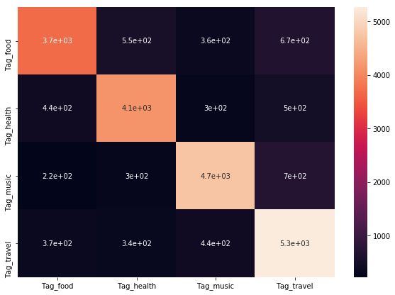

```python
args = {"stem": False, "n_grams":1}
model1, preds1 = train_model(df_train, df_test, args, min_word_ct = 100,  print_conf=True)
```

Let's look at some test items:

```python
for i, (j , row) in enumerate(df_test.iloc[:5].iterrows()):
    print ("Title: {}\nSubtitle: {}\nActual: {}|Predicted: {}\n".format(row["Title"],row["Subtitle"],row["label"], preds1[i] ))
```

```
Title: palmetto has been the standard organic complement
Subtitle: palmetto has been the standard organic complement for Native Americans. It not only encourages healthful hair, but also stops DHT production, which a metabolite Slim U androgenic hormone or testosterone that leads to a defieicency Slim U hair
Actual: Tag_food|Predicted: Tag_food

Title: Tortilla tropical ice cream sundae
Subtitle: This should have been a Summer post when the sun was high in the sky blazing down on us and we were
Actual: Tag_food|Predicted: Tag_food

Title: Relax in Fiji with a Vacation to Taveuni Palms Resort
Subtitle: Relax in Fiji with a Vacation to Taveuni Palms Resort
Actual: Tag_travel|Predicted: Tag_travel

Title: Lisbon will steal your heart if you let it.
Subtitle: On embracing a new city
Actual: Tag_food|Predicted: Tag_travel

Title: 4 Places to Visit near Bangalore during the Monsoons
Subtitle: For all the people out with travel bugs inside their heads, seeking for some wanderlust, Bangalore has some of the most awesome places to treat you on a weekend trip. Places
Actual: Tag_travel|Predicted: Tag_travel
```

```python
for i, (j , row) in enumerate(df_test.iloc[:30].iterrows()):
    if row["label"] != preds1[i]:
        print ("Title: {}\nSubtitle: {}\nActual: {}|Predicted: {}\n".format(row["Title"],row["Subtitle"],row["label"], preds1[i] ))
```

```
Title: Lisbon will steal your heart if you let it.
Subtitle: On embracing a new city
Actual: Tag_food|Predicted: Tag_travel

Title: How Busyness is Actually Killing You
Subtitle: I met a person this week and asked him to tell me about himself.
Actual: Tag_health|Predicted: Tag_music

Title: fun
Subtitle: Thats all, Im goneThats my life, nothing is sacredI dont fall in love, I
Actual: Tag_music|Predicted: Tag_travel

Title: Wichita On Time Plumbing, Heating & Air
Subtitle: Wichita On Time Plumbing, Heating & Air for Furnace Services
Actual: Tag_food|Predicted: Tag_health

Title: Social enterprising for NGOs no longer just a buzz word
Subtitle: The work of non-governmental organizations (NGOs) protecting the environment, helping the sick and needy, preserving arts and culture is by nature unprofitable. Traditionally, NGOs rely on the goodwill and generosity of others to
Actual: Tag_health|Predicted: Tag_travel

Title: Mentor
Subtitle: John had a special gift. He was the minister at a church we were drawn to, based on the effect we saw that it had on a couple we knew. Wed gone
Actual: Tag_health|Predicted: Tag_music

Title: Nobody was ready for this
Subtitle: The week following the eruption of Fuego Volcano in Guatemala
Actual: Tag_travel|Predicted: Tag_music
```

To demonstrate the importance of the amount of data, let's plot a quick **learning curve**:

We train the model for subsets of the training data ranging from 2% to 20%. It can be seen that evaluation scores (for the particular features & model!) start to converge at about 5000 documents .

```
<module 'matplotlib.pyplot' from '/misc/DLshare/home/rpvfq826/.conda/envs/myenv/lib/python3.6/site-packages/matplotlib/pyplot.py'>
```

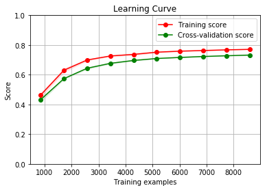

```python
from text_classification_tutorial import plot_learning_curve
args = {"stem": False, "n_grams":1}
cv = model_selection.StratifiedKFold(n_splits=5, shuffle=True)
estimator =  linear_model.LogisticRegression(penalty = "l1", C=0.01, solver = "saga", class_weight="balanced", multi_class = "ovr")
X_train, X_test, vocab = generate_features(args, df_train, df_test, min_word_ct=100)
plot_learning_curve(estimator, "Learning Curve", X_train, df_train["label"], ylim=(0,1), cv=cv,
                        n_jobs=-1, train_sizes=np.linspace(.02, 0.2, 10))
```

#### Experiment II: 1-grams, min_word_ct=5

We see that the result is **much (!) better** than for min_word_ct = 100: Words that appear only in a few documents turn out to be rather useful (see e.g., "weight" in "Tag_health").

```python
args = { "stem":  False , "n_grams":1}
train_model(df_train, df_test, args,min_word_ct=5)
```

```
Number of features: 18248
Best mean CV weighted f1-score is 0.836 at parameters {'C': 0.01}
Top coefficients
           Tag_food   Tag_health     Tag_music     Tag_travel
0       music -0.78  music -0.88    music 1.25    music -0.83
1         food 0.66   health 0.4    food -0.68    travel 0.59
2      travel -0.33  travel -0.4   travel -0.5     food -0.55
3   restaurant 0.32   food -0.29    songs 0.43   health -0.45
4  restaurants 0.27  songs -0.26  health -0.39    songs -0.31
5       songs -0.25  album -0.26    album 0.39    album -0.28
6       album -0.24   trip -0.25     song 0.36      trip 0.27
7      cooking 0.23   song -0.24   albums 0.29     song -0.26
8       recipe 0.21  weight 0.21     band 0.26  healthy -0.25
9        tour -0.21    tour -0.2  musical 0.25    foods -0.19

Non-zero coefficients: 4767 out of 72992

Evaluation scores on test set:
              precision    recall  f1-score   support

    Tag_food       0.83      0.80      0.82      5273
  Tag_health       0.84      0.84      0.84      5379
   Tag_music       0.89      0.87      0.88      5965
  Tag_travel       0.83      0.87      0.85      6407

   micro avg       0.85      0.85      0.85     23024
   macro avg       0.85      0.84      0.85     23024
weighted avg       0.85      0.85      0.85     23024
```

#### Experiment III: 1-grams, word_count=5, stemming

Evaluation scores are marginally better than without stemming.

```python
args = {"stem": True, "n_grams":1}
model3, preds3  = train_model(df_train, df_test, args,min_word_ct=5)
joblib.dump(model3, 'logreg_wct5_stem_1gram.joblib')
```

```
Number of features: 13957
Best mean CV weighted f1-score is 0.84 at parameters {'C': 0.01, 'penalty': 'l1'}
Top coefficients
       Tag_food     Tag_health      Tag_music     Tag_travel
0   music -0.85    music -0.99     music 1.37    music -0.88
1     food 0.67   travel -0.51     food -0.74    travel 0.73
2  restaur 0.45    health 0.41   travel -0.64      food -0.6
3  travel -0.37     song -0.41      song 0.63     song -0.46
4    song -0.36    album -0.35     album 0.54   health -0.45
5   album -0.32     food -0.28   health -0.39    album -0.39
6    recip 0.27  restaur -0.27      band 0.31      trip 0.28
7     cook 0.27     trip -0.26    artist 0.29  restaur -0.27
8    tour -0.26     tour -0.24  musician 0.26      eat -0.26
9     cake 0.21   artist -0.22  playlist 0.25  healthi -0.25

Non-zero coefficients: 3861 out of 55828

Evaluation scores on test set:
              precision    recall  f1-score   support

    Tag_food       0.84      0.80      0.82      5273
  Tag_health       0.84      0.85      0.84      5379
   Tag_music       0.89      0.87      0.88      5965
  Tag_travel       0.83      0.87      0.85      6407

   micro avg       0.85      0.85      0.85     23024
   macro avg       0.85      0.85      0.85     23024
weighted avg       0.85      0.85      0.85     23024
```

```
['logreg_wct5_stem_1gram.joblib']
```

#### Experiment IV: 1-and 2-grams, stemming

Including 2-grams only leads to another marginal improvement.

```python
args = {"stem": True,  "n_grams":2}
train_model(df_train, df_test, args, min_word_ct = 5)
```

```
Number of features: 30622
Best mean CV weighted f1-score is 0.841 at parameters {'C': 0.01}
Top coefficients
       Tag_food     Tag_health      Tag_music     Tag_travel
0    music -0.7    music -0.76     music 1.13    music -0.73
1     food 0.68   travel -0.49      food -0.6    travel 0.71
2  restaur 0.44    health 0.44   travel -0.56     food -0.57
3  travel -0.39     song -0.36      song 0.55   health -0.42
4    song -0.33     food -0.32     album 0.46      song -0.4
5     cook 0.28    album -0.29   health -0.37    album -0.33
6   album -0.28     trip -0.26      band 0.28      trip 0.29
7    recip 0.27  restaur -0.25    artist 0.28  restaur -0.28
8    tour -0.24     tour -0.21  musician 0.25      eat -0.25
9     cake 0.21     weight 0.2      eat -0.24  healthi -0.24

Non-zero coefficients: 5366 out of 122488

Evaluation scores on test set:
              precision    recall  f1-score   support

    Tag_food       0.84      0.80      0.82      5273
  Tag_health       0.85      0.84      0.85      5379
   Tag_music       0.89      0.87      0.88      5965
  Tag_travel       0.83      0.87      0.85      6407

   micro avg       0.85      0.85      0.85     23024
   macro avg       0.85      0.85      0.85     23024
weighted avg       0.85      0.85      0.85     23024
```

### B) Support Vector Machine

Let's try a linear support vector machine (SVM) algorithm. As the decision boundaries learned by logistic regression and support vector machine are both linear, we typically would not expect huge differences in evaluation scores. As opposed to SVM, logistic regression naturally provides a probabilistic output (probabilities that a documents is in each class), which can be useful in practice.

The evaluation scores are slightly inferior to those of the logistic regression.

```python
args = { "stem": True, "n_grams":1}
train_model(df_train, df_test, args, min_word_ct = 5,  alg = "svm", param_grid = np.logspace(-2,2,5 ))
```

```
Number of features: 13957
Best mean CV weighted f1-score is 0.831 at parameters {'C': 0.01}
Top coefficients
       Tag_food      Tag_health      Tag_music    Tag_travel
0   music -0.27     music -0.36      music 0.5   music -0.28
1     food 0.22    travel -0.16      song 0.26   travel 0.26
2  restaur 0.16     health 0.14     album 0.24    food -0.22
3   travel -0.1      song -0.11     food -0.22    song -0.16
4      cook 0.1     album -0.11   travel -0.19  health -0.13
5     song -0.1       food -0.1      band 0.14   album -0.13
6     cake 0.09  healthcar 0.08     piano 0.12      eat -0.1
7    recip 0.09    artist -0.08  musician 0.12      trip 0.1
8   album -0.09     doctor 0.07    artist 0.12  restaur -0.1
9     chef 0.09     clinic 0.07  playlist 0.11    diet -0.09

Non-zero coefficients: 8091 out of 55828

Evaluation scores on test set:
              precision    recall  f1-score   support

    Tag_food       0.81      0.79      0.80      5273
  Tag_health       0.83      0.83      0.83      5379
   Tag_music       0.88      0.86      0.87      5965
  Tag_travel       0.83      0.86      0.84      6407

   micro avg       0.84      0.84      0.84     23024
   macro avg       0.84      0.83      0.84     23024
weighted avg       0.84      0.84      0.84     23024
```

### C) Recurrent Neural Network

The features used in the above models do not consider the order of words within the document (1-grams), or only to the extent of neighbouring words (2-grams). (Including higher-order n-grams quickly explodes the number of features, which may decrease evaluation scores.)

**A recurrent neural network takes into account the order of tokens in the texts.**

We adapt https://www.kdnuggets.com/2018/07/overview-benchmark-deep-learning-models-text-classification.html to our dataset. See also https://github.com/keras-team/keras/tree/master/examples.

```python
from keras.preprocessing.text import Tokenizer
from keras.preprocessing.text import text_to_word_sequence
from keras.preprocessing.sequence import pad_sequences

from keras.models import Model
from keras.models import Sequential

from keras.layers import Input, Dense, Embedding, Conv1D,  Conv2D, MaxPooling1D, MaxPool2D
from keras.layers import Reshape, Flatten, Dropout, Concatenate
from keras.layers import SpatialDropout1D, concatenate
from keras.layers import GRU, Bidirectional, GlobalAveragePooling1D, GlobalMaxPooling1D

from keras.callbacks import Callback
from keras.optimizers import Adam
from keras.callbacks import ModelCheckpoint, EarlyStopping
from keras.models import load_model
from keras.utils.vis_utils import plot_model
```

We will split the training data set into a train and a validation data set:

```python
df_train2, df_val, y_train, y_val = model_selection.train_test_split(\
        df_train, df_train["label"], stratify = df_train["label"] ,random_state= 11, test_size = 0.2)
labels = np.unique(df_train["label"])
```

Tokenize the text:

```python
MAX_NB_WORDS = 100000
tokenizer = Tokenizer(num_words=MAX_NB_WORDS) #By default, this tokenizer splits on '!"#$%&()*+,-./:;<=>?@[\]^_`{|}~'
tokenizer.fit_on_texts(df_train2["all_text"])
x_train2 = tokenizer.texts_to_sequences(df_train2["all_text"])
x_val = tokenizer.texts_to_sequences(df_val["all_text"])
x_test = tokenizer.texts_to_sequences(df_test["all_text"])
```

LSTM's take into account the position of words, and we must "fill in" shorter token sequences with dummmies.

We'll determine the maximum token sequence length first.

```python
print ("Maximum sequence length training: {}".format(np.max([len(v) for v in x_train2])))
```

```
Maximum sequence length training: 77
```

```python
MAX_LENGTH = 80
padded_train_sequences = pad_sequences(x_train2, maxlen=MAX_LENGTH)
padded_val_sequences = pad_sequences(x_val, maxlen=MAX_LENGTH)
padded_test_sequences = pad_sequences(x_test, maxlen=MAX_LENGTH)
```

Map the labels into a binary matrix of shape (nr_classes, nr_blogs):

```python
from keras.utils import to_categorical
label_map = { v: i for i,v in enumerate(np.unique(df["label"]))}
Ytrain = to_categorical([label_map[y] for y in y_train], num_classes=6)
Yval = to_categorical([label_map[y] for y in y_val], num_classes=6)
Ytest = [label_map[y] for y in y_test]
```

Some comments on the model:

- The embedding layer: A vector based representation of the words (as opposed to the bag-of-words representation). Similar words have smaller euclidean distance between their respective vectors. Here, we use a random initialization for the word embeddings, which are then iteratively improved during training.
- Dropout: Randomly drop (set to 0) 30% of embeddings at each update to reduce overfitting: This takes the role of regularization.
- Gated recurrent unit (GRU): The actual RNN architecture. GRU's are an (faster to train) alternative to LSTM's.
- Pooling: The recurrent network outputs latent vectors for each word (that contain long-range information as a result of the RNN). To extract the most important information in the latent vectors, a concatenation of their average and their maximum (elementwise) are considered.
- Categorical cross entropy is in fact the same loss function as in a multinomial logistic regression
- Metrics: For reasons of simplicity we tune using accuracy (as our classes are relatively balanced, this should yield the same results as tuning with weighted f1-score).
- Adam optimizer (adaptive learning rates), empirically shown to lead to faster convergence than other stochastic optimization methods
- Softmax output: This is the same transformation to a probabilistic output as in the case of multinomial logistic regression.

```python
def get_rnn_model(embedding_dim= 300, embedding_matrix=np.random.random((MAX_NB_WORDS, 300))):

    inp = Input(shape=(MAX_LENGTH, ))
    x = Embedding(input_dim=MAX_NB_WORDS, output_dim=embedding_dim, input_length=MAX_LENGTH,
                  weights=[embedding_matrix], trainable=True)(inp)
    x = SpatialDropout1D(0.3)(x)
    x = Bidirectional(GRU(100, return_sequences=True))(x)
    avg_pool = GlobalAveragePooling1D()(x)
    max_pool = GlobalMaxPooling1D()(x)
    conc = concatenate([avg_pool, max_pool])
    outp = Dense(6, activation="softmax")(conc)

    model = Model(inputs=inp, outputs=outp)
    model.compile(loss='categorical_crossentropy',
                  optimizer='adam',
                  metrics=["accuracy"])
    return model

rnn_simple_model = get_rnn_model()
```

Train the model:

```python
filepath="rnn_models/no_embeddings/weights-improvement-{epoch:02d}-{val_acc:.4f}.hdf5"
checkpoint = ModelCheckpoint(filepath, monitor='val_acc', verbose=1, save_best_only=True, mode='max')

batch_size = 256
epochs = 10

history = rnn_simple_model.fit(x=padded_train_sequences,
                    y=Ytrain,
                    validation_data=(padded_val_sequences, Yval),
                    batch_size=batch_size,
                    callbacks=[checkpoint],
                    epochs=epochs,
                    verbose=1)
```

```
Train on 42976 samples, validate on 10744 samples

Epoch 00001: val_acc improved from -inf to 0.61011, saving model to rnn_models/no_embeddings/weights-improvement-01-0.6101.hdf5

Epoch 00002: val_acc improved from 0.61011 to 0.76592, saving model to rnn_models/no_embeddings/weights-improvement-02-0.7659.hdf5

Epoch 00003: val_acc improved from 0.76592 to 0.81562, saving model to rnn_models/no_embeddings/weights-improvement-03-0.8156.hdf5

Epoch 00004: val_acc improved from 0.81562 to 0.82781, saving model to rnn_models/no_embeddings/weights-improvement-04-0.8278.hdf5

Epoch 00005: val_acc improved from 0.82781 to 0.83507, saving model to rnn_models/no_embeddings/weights-improvement-05-0.8351.hdf5

Epoch 00006: val_acc did not improve from 0.83507

Epoch 00007: val_acc improved from 0.83507 to 0.83972, saving model to rnn_models/no_embeddings/weights-improvement-07-0.8397.hdf5

Epoch 00008: val_acc did not improve from 0.83972

Epoch 00009: val_acc did not improve from 0.83972

Epoch 00010: val_acc did not improve from 0.83972
```

```python
best_rnn_simple_model = load_model('rnn_models/no_embeddings/weights-improvement-07-0.8397.hdf5')
y_pred_prob = best_rnn_simple_model.predict(padded_test_sequences, verbose=1, batch_size=2048)
y_pred = np.argmax(np.array(y_pred_prob), axis=1)
```

We see that the model scores a bit lower than our best logistic regression models.

Note that we **lose the interpretability of the model**: There are no longer model coefficients that gives us some insights into what features are most responsible for a given prediction.

```python
print (metrics.classification_report(Ytest, y_pred, target_names = np.unique(df_test["label"])))
```

```
              precision    recall  f1-score   support

    Tag_food       0.81      0.81      0.81      5273
  Tag_health       0.81      0.85      0.83      5379
   Tag_music       0.89      0.87      0.88      5965
  Tag_travel       0.85      0.84      0.84      6407

   micro avg       0.84      0.84      0.84     23024
   macro avg       0.84      0.84      0.84     23024
weighted avg       0.84      0.84      0.84     23024
```

### D) Recurrent neural network with pretrained glove-embeddings

Instead of using randomly initialized word embeddings, we used word embeddings that were pre-trained on a large corpus (wikipedia): Thus, we use external knowledge about semantical and syntactical relationships between words.

```python
#Create dictionary of embeddings
def get_coefs(word, *arr):
    try:
        return word, np.asarray(arr, dtype='float32')
    except:
        return None, None
embeddings_index = dict(get_coefs(*o.strip().split()) for o in open('embeddings/glove.6B.300d.txt'))
embed_size=300
for k in list(embeddings_index.keys()):
    v = embeddings_index[k]
    try:
        if v.shape != (embed_size, ):
            embeddings_index.pop(k)
    except:
        pass
```

```python
"""
initialize embedding matrix to normal dist with mean and std of all embeddings (some tokens do not have embedding vector)
"""
values = list(embeddings_index.values())
all_embs = np.stack(values)

emb_mean, emb_std = all_embs.mean(), all_embs.std()
word_index = tokenizer.word_index
nb_words = MAX_NB_WORDS
embedding_matrix = np.random.normal(emb_mean, emb_std, (nb_words, embed_size))

oov = 0
for word, i in word_index.items():
    if i >= MAX_NB_WORDS: continue
    embedding_vector = embeddings_index.get(word)
    if embedding_vector is not None:
        embedding_matrix[i] = embedding_vector
    else:
        oov += 1

print("Number of words {}, {} of which not have pre-trained embedding vector".format(len(word_index), oov))
```

```
Number of words 84719, 32504 of which not have pre-trained embedding vector
```

```python
rnn_glove_model = get_rnn_model(embedding_matrix = embedding_matrix , embedding_dim = 300)

filepath="rnn_models/glove_embeddings/weights-improvement-{epoch:02d}-{val_acc:.4f}.hdf5"
checkpoint = ModelCheckpoint(filepath, monitor='val_acc', verbose=1, save_best_only=True, mode='max')

batch_size = 256
epochs = 10
history = rnn_glove_model.fit(x=padded_train_sequences,
                    y=Ytrain,
                    validation_data=(padded_val_sequences, Yval),
                    batch_size=batch_size,
                    callbacks=[checkpoint],
                    epochs=epochs,
                    verbose=1)
```

```
Train on 42976 samples, validate on 10744 samples

Epoch 00001: val_acc improved from -inf to 0.84187, saving model to rnn_models/glove_embeddings/weights-improvement-01-0.8419.hdf5

Epoch 00002: val_acc improved from 0.84187 to 0.85676, saving model to rnn_models/glove_embeddings/weights-improvement-02-0.8568.hdf5

Epoch 00003: val_acc improved from 0.85676 to 0.86067, saving model to rnn_models/glove_embeddings/weights-improvement-03-0.8607.hdf5

Epoch 00004: val_acc improved from 0.86067 to 0.86309, saving model to rnn_models/glove_embeddings/weights-improvement-04-0.8631.hdf5

Epoch 00005: val_acc improved from 0.86309 to 0.86383, saving model to rnn_models/glove_embeddings/weights-improvement-05-0.8638.hdf5

Epoch 00006: val_acc did not improve from 0.86383

Epoch 00007: val_acc did not improve from 0.86383

Epoch 00008: val_acc did not improve from 0.86383

Epoch 00009: val_acc did not improve from 0.86383

Epoch 00010: val_acc did not improve from 0.86383
```

```python
best_rnn_glove_model = load_model('rnn_models/glove_embeddings/weights-improvement-05-0.8638.hdf5')
y_pred_prob = best_rnn_glove_model.predict(padded_test_sequences, verbose=1, batch_size=2048)
y_pred = np.argmax(np.array(y_pred_prob), axis=1)
```

We achieve an improvement over the logistic regression models!

```python
print (metrics.classification_report(Ytest, y_pred, target_names = np.unique(df_test["label"])))
```

```
              precision    recall  f1-score   support

    Tag_food       0.82      0.84      0.83      5273
  Tag_health       0.86      0.86      0.86      5379
   Tag_music       0.90      0.90      0.90      5965
  Tag_travel       0.88      0.86      0.87      6407

   micro avg       0.86      0.86      0.86     23024
   macro avg       0.86      0.86      0.86     23024
weighted avg       0.86      0.86      0.86     23024
```